# Suche nach potentiell unterbewerteten Aktien mittels DCF und P/B Value

Justin König

12.09.2022

## Motivation

Durch Corona und den darauffolgenden Crash an den Börsen, sowie der boom der Neobroker kam es in den letzten Jahren zu einer stark steigenden Zahl von Kleinanlegern an den Aktienmärkten.(Borowski 2021) Das Ziel dieser Arbeit besteht darin, ein möglichst einfach zu bedienendes Tool zu kreieren, welches mit dem Grundgedanken des Value Investing, den intrinisischen Wert mittels Discounted Free Cash Flow berechnet. Dieser Implizierte Aktienpreis, soll der Auswahl von Unternehmen dienen, welche im Anschluss genauer betrachtet werden können.

## Einleitung

Im Finanzwesen spielt das Bewerten von Unternehmen mit Hilfe von DCF-Modellen eine wichtige Rolle. Bei dem intrinsic value handelt es sich um den aktuellen wahren Wert eines Unternehmens unter Berücksichtigung zukünftiger erwarteter Geschäftzahlen(Lee, Myers, and Swaminathan 1999)

Die ermittlung eines intrinisischen Wertes mittels DCF-Models, kann hierbei auf zwei Arten geschehen, zum einen mit dem sogegannten free cash flow to equity oder auch levered free cash flow und dem in dieser Arbeit genutzen unlevered free cash flow (uFCF). Beim uFCF wird wie der Name sagt kein Hebel mit einbezogen (Hebel steht hierbei für Schulden). Aus diesem uFCF kann im Anschluss der aktuelle impliezierte Aktienpreis des Unternehmens berechnet werden.

## Unlevered Free Cash Flow Berechnung

Um den uFCF zu berechnen, müssen zunächst einige Unternehmenszahlen projeziert werden. Zunächst wird der mittelwert des Wachstums aus den vergangen Revenuezahlen und den Zahlen der Analysten für die kommenden zwei Jahre gebildet. Mit Hilfe dieses Mittelwertes werden der Revenue weiter projeziert. Anhand des Revenues kann nun bezug auf die zukünftigen EBIT (earnings before interest and taxes), D&A (Depreciation & amortization), CapEx (capital expenditure) und cNWC (change in net working capital) genommen werden. Hierbei berechnet sich der uFCFwie folgt.(Damadoran, n.d.)

$$uFCF =
EBIT*(1-taxrate)+DA-CapEx-cNWC$$

Für die weitere Berechnung des implied share price wird die sogeannte required rate of return benötigt (RRR), diese kann angenommen werden, da sie den return welcher ein Asset hervorbringen soll, darstellt. Jedoch kann diese mittels dem weigthed average cost of capital (WACC) auch berechnet werden.(Grüninger and Kind 2013)

$$WACC = r_e*(1-L)+r_d*(1-T_c)*L$$
mit $r_e$: cost of equity L: leverage ratio (Debt/Value) $r_d$: cost of debt, $T_c$: tax rate

Aus dem uFCF und der RRR kann nur der Firm Value berechnet werden.(Damadoran, n.d.)

$FirmValue = \sum_{t=1}^t \frac {uFCF_t}{(1+RRR)^t}$ mit $FCFF_t$ = Free Cash Flow in year t

Es gilt zu beachten, das in dieser Arbeit eine mid Year conversion angewandt wird, wodurch t in Jahren mit dem Discount Factor ersetzt wird. Dies entspringt der Annahme, das ein unternehmen konstant Cash Flow generiert und somit der Fortschritt des Fiscal Jahres berücksichtigt werden muss.

$Terminalvalue = uFCF * \frac{1+TGR}{RRR-TGR}$

$pTerminalValue = \frac {{Terminalvalue_n}}{(1+RRR)^discfac}$

Der Enterprise Value ergibt sich daraufhin aus folgenden Formel.(Dong 2018)

$Enterprisevalue = pTerminalvalue+Firmvalue$

Addiertt man nun noch das Cash Vermögen des Unternehmens und zieht die Schulden ab gelant man zum Equity Value

Teilt man dieses durch die Aktien im Umlauf erhält man den implizierten Aktienpreis.

Es stellt sich die Frage, nach der Möglichkeit einen Data Scraper zu konstruieren, welcher kostenfreie Daten nutzt, um mit diesem die nötigen Informationen zu sammeln, welche für die uFCF und anschließend implied share price kalkulation gebraucht werden.

## Aufbau

Zunächst wird durch die Data Scraper die Daten für die DCF und den Price to Book value (P/B) von den zugeteilten Websiten gescraped. Die Ticker der angegebenen Unternehmen dienen als Pfad für das extrahieren der HTML Texte aus den URLs. Diese HTML Texte werden im Anschluss nach Stichwörtern durchsucht und die Zwischenstellen extrahiert. Diese Zwischenstellen dienen in Form von data frames als Grundlage für die Berechnung des Intrinsic Values bzw. bei Banken der Berechnung des P/B-Values.

## Daten

Alle Daten mit der Ausnahme des country risk premiums stammen von Yahoo Finance. Das Country Risk Premium wird der Webiste von Professor Aswath Damodaran mit Hilfe eines HTML nodes in Form einer Tabelle entnommen, und als data frame dargestellt. Für das country risk premium nutzt Professor Aswath das implied equity risk premium des Aktieindexes S&P500.(Damodaran 2022) Die Daten von Yahoo Finances werden mit Hilfe des packages rvest in Form des gesamten bodys als Text ausgegeben. In diesem Text sind die benötigten Zahlen und Daten wie Währung oder Industry enhalten. Diese werden mit qdapRegex extrahiert und in Form von data frames bis zur Berechnung gespeichert. Diese Daten werden von Yahoo Finance erhoben und stammen aus den Berichten der Unternehmen, sind jedoch leider in manchen Fällen unvollständig oder unterschiedlich gelabelt.

Pro Unternehmen werden zwei Listen mit je fünf bzw. drei data frames und einem einzelnen data frame ausgegeben. In Summe sind hierin 46 Datenpunkte enthalten. Die Umfänge der gesamten Daten unterscheiden sich je nach dem wieviele Unternehmen untersucht werden sollen.

## Software

Das Programm wurde in RStudio mit der R-Version: 4.1.1 auf einem Laptop (Lenovo ThinkPad T490s) angefertig. Folgende packages wurden verwendet.

- tidyverse
  - ggplot2
  - dplyr
  - tibble
- rvest
- quantmod
- tidyquant
- GridExtra
- DiagrammeR
- gt
- glue

Bei tidyverse handelt es sich um ein package in welchem mehrere packages enthalten sind. Hierrunter fallen ggplot2 (dient der visualisierung), dplyr (manipulation von data frames) , tidyr (umwandlung von data frames), readr(lesen von data aus z. B. CSVs), purrr(erleichtert Arbeiten mit Vektoren und Funktionen), tibble(ermöglicht data frame anderst zu formatieren), stringr(erleichtert das Arbeiten mit strings) und forcats(hilft bei der Kategorisierung von variablen). Es wurden jedoch nicht alle packeges die in tidyverse enthalten sind in dieser Arbeit verwendet. Dei den verwendeten handelt es sich um ggplot2, dplyr und tibble. Zur Umwandlung des Formats von data frames wurde das package reshape2 genutzt.

Als Kernstück der Scraper dient das package rvest, dieses ermöglicht das Sammeln von Daten von Websiten. Zur Sammlung von aktuellen Aktienkursen wird das quantmod genutzt, während tidyquant die verbindunge zwischen quantmod und den tidyverse packages schafft.

GridExtra ermöglicht ein schönes einfügen von Tabellen in Plots welche mit ggplot2 angefertigt wurden. Mit DiagrammeR lassen sich Flow Charts erstellen und mit dem package gt ergeben sich Möglichkeiten schöne Tabellen zu erstellen. Mit glue können Variablen eingefügt und auch Verbunden werden, ähnlich wie mit der paste Funktion, jedoch kürzer und übersichtlicher bei mehreren Variablen.

```r
# Die Ticker der ausgesuchten Firmen, werden mittels eines Vektors der
# Variablen Ticker zugewiesen

Ticker <-c("EOAN.DE", "GS", "MSFT", "AAPL", "BAC", "CRM", "NVDA", "NKE", "MS")
# Ticker <- "NKE"
```

```r
# Die folgenden Funktionen sind eigentlich dazu gedacht gesourced zu werden
# werden jedoch der vollständigkeitshalber hier aufgeführt

# extrahiert den Preis, die Industry, EPS (earnings per share) und den
# Firmennamen von Yahoo Finances und berechnet den PE (Price to earnings)

basics_data <- function(ticker) {

  # fügt der URL mit hilfe der paste0 funktion die Variable ticker hinzu
  # die 0 an paste bewirkt das weglassen von leerzeichen
  url_profile <- paste0('https://finance.yahoo.com/quote/', ticker)

  # weist der Variablen den HTML Text der URL zu
  # hier werden der HTML Text des Profils der Firma hinzugefügt
  html_profile <- read_html(url_profile) %>% html_node('body') %>%
    html_text() %>%
    toString()

  # extrahiert den HTML Text der financials Seite von Yahoo Finance der Firma
  url_fin <- paste0('https://finance.yahoo.com/quote/',
                    ticker, '/financials?p=', ticker)
  html_fin <- read_html(url_fin) %>% html_node('body') %>%
    html_text() %>% toString()

  # extrahiert aus dem HTML Text den aktuellen Börsenpreis der Firma
  # die qdapRegex Funktion extrahiert hierbei alle Textpassagen zwischen den
  # Schlagwörtern. Da die Zahlen aus dem Text als nicht numerisch extrahiert
  # wird, müssen diese im FOlgenden immer in numerische charactere umgewandelt
  # werden.
  # Im Anschluss wird die Zahl auf zwei Nachkommastellen gerundet
  Price <- qdapRegex::ex_between(html_profile, "currentPrice\":{\"raw\":",
                                 ",\"fmt\":\"")[[1]]
  Price <- as.numeric(Price)
  Price <- round(Price, 2)

  # Extrahiert den Subsektor der Firma, da mehrere Textpassagen extrahiert werden
  # wird nur der erste genutzt (die gewollte Industry)
  Industry <- qdapRegex::ex_between(html_profile, "industry\":\"",
                                    "\"")[[1]]
  Industry <- Industry[1]

  # extrahiert die Währung
  Currency <- qdapRegex::ex_between(html_fin, "financialCurrency\":\"",
                                    "\"},\"price")[[1]]
  Currency <- data.frame(Currency)

  # extrahiert den EPS

  EPS <- qdapRegex::ex_between(html_profile, "EPS (TTM)",
                               "Earnings")[[1]]
  EPS <- EPS[1]
  EPS <- as.numeric(EPS)

  # berechnen den PE und rundet auf zwei Nachkommastellen

  PE <- round(Price/EPS,2)

  # extrahiert den Firmennamen

  Company <- qdapRegex::ex_between(html_profile, "\":{\"title\":\"",
                                   " (")[[1]]
  Company <- Company[1]

  # weist einer Liste die Variablen Price, Industry, PE, and Company zu und
  # gibt diese aus

  out <- list (
    Price = Price,
    Industry = Industry,
    PE = PE,
    Company = Company,
    Currency = Currency
  )
  return(out)
}
```

```r
# eine while Schleife, nimmt den Ticker und weist diesem die korrekte Industry,
# den Preis und P/E, sowie den Firmennamen zu
# in Klammern steht toassaign_df, da bei nutzen der Funktion, dieser zugewiesen
# werden kann

basics_assignement <- function(toassaign_df) {

  # x <- 1, damit die while Schleife in der ersten Reihe des data frames
  # beginnt zu zählen. Erstellt einen data frame aus toassaign_df, Industry,
  # Price und P/E und füllt die Reihen mit den Variablen
  x<-1
  Company <- "Company"
  Company <- data.frame(Company)
  toassaign_df <- bind_cols(Company, toassaign_df)
  Industry<-"Industry"
  Industry<-data.frame(Industry)
  toassaign_df<- bind_cols(toassaign_df, Industry)
  Currency<-"Currency"
  Currency<-data.frame(Currency)
  toassaign_df<- bind_cols(toassaign_df, Currency)
  Price<-"Price"
  Price<-data.frame(Price)
  toassaign_df<- bind_cols(toassaign_df, Price)
  PE <- "P/E"
  PE <- data.frame(PE)
  toassaign_df<- bind_cols(toassaign_df, PE)

  # entfernt die Variablen, damit sie mit attach() genutz werden können
  rm(Company,Industry,Price,PE, Currency)

  # es wird eine while schleife erstellt, welche von der ersten Reihe (x=1) bis
  # zur letzten Reihe (nrow) des data frames zählt
  while (x<=nrow(toassaign_df)) {
    # der aktuelle Ticker wird zugewiesen und die function basics_data wird
    # angewended um die benötigten datan des tickers zu scrapen
    ticker <- toassaign_df[paste(x),2]
    basics <- basics_data(paste(ticker))

    # attach ermöglicht hier den direkten zugriff auf die col Namen
    attach(basics)

    # Gescrapten Daten werden dem data frame zugewiesen
    # Zudem werden Statments gedruckt, welche den Nutzer wissen lässt,
    # an welcher Stelle die zuweisung aktuell ist
    toassaign_df[paste(x),1] <- Company
    print(paste("assining Industry", x, "of",nrow(toassaign_df), "to",
                Company))
    toassaign_df[paste(x),3] <- Industry
    print(paste("assining Currency", x, "of",nrow(toassaign_df), "to",
                Company))
    toassaign_df[paste(x),4] <- Currency
    print(paste("assining Price", x, "of",nrow(toassaign_df), "to",
                Company))
    toassaign_df[paste(x),5] <- Price
    print(paste("calculating and assining P/E", x, "of",nrow(toassaign_df),
                "to", Company))
    toassaign_df[paste(x),6] <- round(PE,2)

    # addiert x + 1 damit die nächste Reihe bearbeitet wird
    # detach wird angewandt, damit die daten nicht maskiert werden
    x<-x+1
    detach(basics)
  }
  # gibt eine Liste mit den gescrapten und zugewiesenen daten aus
  out <- list(
    list = toassaign_df
  )
  return(out)
}
```

```r
# Die ergebnisse dieses chunks werden nicht in dem HTML Dokument ausgegeben,
# da bei vielen Tickern ein großer output entsteht

# Erstellt einen data frame aus Ticker
Stocks <- data.frame(Ticker)

# die Variable Ticker wird nicht mehr benötigt und wird entfernt
rm(Ticker)

# wendend die Funktion basics_assignment auf den data frane Stocks an, als
# Ticker der Funktion werden die in Klammern geschriebenen Stocks genutzt
# und nutzt anschliesend nut den Teil der Listen, welche benötigt wird
Stocks <- basics_assignement(Stocks)
Stocks <- Stocks$list

print(Stocks)
```

```r
# Erstellt eine Funktion, welche die benötigten Daten für die Berechnung des
# Fair Values der Aktien läd die benötigten Variablen sind die Ticker, sowie
# die TGR (Terminal Growth Rate) diese ist das angenommene konstante Wachstum
# mit welche das Unternehmen für immer wächst

DCF_data_scraper <- function(ticker, TGR = 0.025) {

  # es werden diverese URLs  von yahoo mit dem ticker verknüpft und anschließend
  # die HTML Text zugewiesen
  url_profile <- paste0('https://finance.yahoo.com/quote/', ticker)

  # Druckt Statments, damit der User weiß an welchem Punkt sich der scraper
  # befindet
  print("assingning urls and loading HTML")

  url_fin <- paste0('https://finance.yahoo.com/quote/',
                    ticker, '/financials?p=', ticker)
  html_fin <- read_html(url_fin) %>% html_node('body') %>%
    html_text() %>% toString()
  url_cf <- paste0('https://finance.yahoo.com/quote/',
                   ticker, '/cash-flow?p=', ticker)
  html_cf <- read_html(url_cf) %>% html_node('body') %>% html_text() %>%
    toString()
  url_bonds <- 'https://finance.yahoo.com/bonds'
  html_bonds <- read_html(url_bonds) %>%
    html_node('body') %>%  html_text() %>% toString()
  url_stats <- paste0('https://finance.yahoo.com/quote/',
                      ticker, '/key-statistics?p=', ticker)
  html_stats <- read_html(url_stats) %>% html_node('body') %>%
    html_text() %>% toString()
  url_balance <- paste0('https://finance.yahoo.com/quote/',
                        ticker, '/balance-sheet?p=', ticker)
  html_balance <- read_html(url_balance) %>% html_node('body') %>%
    html_text() %>% toString()
  url_ana <- paste0('https://finance.yahoo.com/quote/',
                    ticker,'/analysis?p=',ticker)
  html_ana <- read_html(url_ana) %>% html_node('body') %>%
    html_text() %>% toString()

  # ließt HTML Text der URL für das equity risk premium
  url_risk_prem<-read_html(
    'https://pages.stern.nyu.edu/~adamodar/New_Home_Page/datafile/ctryprem.html')

  # da es bei diesem HTML Text Probleme mit qdapRegex gibt wird das
  # equity risk premiummit filfe eines HTML Nodes extrahiert, welcher die
  # Tabelle auf der Website ausgibt
  url_risk_prem <- url_risk_prem %>% html_nodes("td") %>%
    html_text()

  # extrahiert die Jahre in welcher die Finacel Statments herrausgegeben wurden
  # und erstellt einen data frame daraus
  Year <- qdapRegex::ex_between(html_fin, "financialsChart\":{\"yearly\":",
                                "quarterly\":[{\"")[[1]]
  Year <- qdapRegex::ex_between(Year, "{\"date\":",
                                ",\"revenue\"")[[1]]
  yearly_data <- data.frame(Year)

  # extrahiert den Revenue
  print("extracting Revenue")

  TotalRevenue <- qdapRegex::ex_between(html_fin, ",\"revenue\":{\"raw\":",
                                        ",\"fmt\":\"")[[1]]
  TotalRevenue <- TotalRevenue[1:4]
  TotalRevenue <- as.numeric(TotalRevenue)
  TotalRevenue <- data.frame(TotalRevenue)

  yearly_data <- bind_cols(yearly_data, TotalRevenue )

  print("extracting Projected Revenue and number of Analysts")
  # extrahiert den avg. prohected revenue für die kommenden 2 Jahre und die
  # Anzahl der Analysten, welche diese Vorhersage getroffen haben

  ProjRev <- qdapRegex::ex_between(html_ana, "revenueEstimate",
                                   "numberOfAnalysts")[[1]]
  ProjRev <- ProjRev[3:4]
  ProjRev <- c(qdapRegex::ex_between(ProjRev, "\"avg\":{\"raw\":",
                                     ",\"fmt")[[1]],
               qdapRegex::ex_between(ProjRev, "\"avg\":{\"raw\":",
                                     ",\"fmt")[[2]] )
  ProjRev <- as.numeric(ProjRev)
  ProjRev <- data.frame(ProjRev)

  ProjAnalysts <- qdapRegex::ex_between(html_ana, "revenueEstimate",
                                        "yearAgoRevenue")[[1]]
  ProjAnalysts <- ProjAnalysts[3:4]
  ProjAnalysts <- c(qdapRegex::ex_between(ProjAnalysts,
                   "\"numberOfAnalysts\":{\"raw\":", ",\"fmt")[[1]],
                    qdapRegex::ex_between(ProjAnalysts,
                   "\"numberOfAnalysts\":{\"raw\":", ",\"fmt")[[2]])
  ProjAnalysts <- as.numeric(ProjAnalysts)
  ProjAnalysts <- data.frame(ProjAnalysts)
  ProjRev <- bind_cols(ProjRev,ProjAnalysts)

  # Extrahiert den EBIT
  print("extracting EBIT")

  EBIT <- qdapRegex::ex_between(html_fin, "annualOperatingIncome",
                                "annual")[[1]]
  EBIT <- qdapRegex::ex_between(EBIT, "{\"raw\":",
                                ",\"fmt\"")[[1]]
  EBIT <- as.numeric(EBIT[1:4])
  EBIT <- data.frame(EBIT)
  yearly_data <- bind_cols(yearly_data, EBIT)

  # Extrahier den Income Tax Expense
  print("extracting income tax expense")

  IncTaxEx <- qdapRegex::ex_between(html_balance,
              "\"incomeTaxExpense\":{\"raw\":", ",\"fmt\":")[[1]]
  IncTaxEx <- rev(IncTaxEx[5:8])
  IncTaxEx <- as.numeric(IncTaxEx)
  IncTaxEx <- data.frame(IncTaxEx)
  yearly_data <- bind_cols(yearly_data,IncTaxEx)

  # extrahiert Depreciation & Amortization (D&A)
  print("extracting Depreciation & Amortization")

  DandA <- qdapRegex::ex_between(html_fin, "annualReconciledDepreciation",
                                 "trailing")[[1]]
  DandA <- qdapRegex::ex_between(DandA, "\"raw\":",
                                 ",\"fmt\":")[[1]]
  DandA <- DandA[1:4]
  DandA <- as.numeric(DandA)
  DandA <- data.frame(DandA)
  yearly_data <- bind_cols(yearly_data,DandA)

  print("extracting Capital Expenditure")

  # extrahiert CAPEX (Capital Expenditure)
  CAPEX <- qdapRegex::ex_between(html_cf, "\"capitalExpenditures\":",
                                 "\"fmt\"")[[1]]
  CAPEX <- CAPEX[1:4]
  CAPEX <- gsub("{\"raw\":", "", CAPEX, fixed=T)
  CAPEX <- gsub(",", "", CAPEX, fixed=T)
  CAPEX <- as.numeric(CAPEX)
  CAPEX <- CAPEX*-1
  CAPEX <- rev(CAPEX)
  CAPEX <- data.frame(CAPEX)
  yearly_data <- bind_cols(yearly_data, CAPEX)

  # extrahiert NWC () Changein net working capital)
  cNWC <- qdapRegex::ex_between(html_cf, "annualChangeInWorkingCapital",
                                "trailing")[[1]]
  cNWC <- qdapRegex::ex_between(cNWC, "\"raw\":", ",\"fmt\":")[[1]]
  cNWC <-  cNWC[1:4]
  cNWC <- as.numeric(cNWC)
  cNWC <- data.frame(cNWC)
  yearly_data <- bind_cols(yearly_data, cNWC)

  # extrahiert das ende des Fiskaljahres des Unternehmens und berechnet den
  # aktuellen Prozensatz für die später folgende calenderization
  fye <- qdapRegex::ex_between(html_stats, "lastFiscalYearEnd",
                               "heldPercentInstitutions")[[1]]
  fyemonth <- qdapRegex::ex_between(fye, "-", "-")[[1]]
  fyemonth <- as.numeric(fyemonth)
  rateofffye <- fyemonth/12

  # erstellent den data frame T0Data (für aktuelle nicht wiederholende Daten)
  T0Data <- data.frame(rateofffye)

  # extrahiert das Market Cap
  print("extracting Market Cap")

  MarkCap <- qdapRegex::ex_between(html_stats, "trailingMarketCap",
                                   "\"fmt\":\"")[[1]]
  MarkCap <- qdapRegex::ex_between(MarkCap, "\"raw\":", ",")[[1]]
  MarkCap <- as.numeric(MarkCap)
  MarkCap <- data.frame(MarkCap)
  T0Data <- bind_cols(T0Data,MarkCap)

  # extrahiert die 10 Year Bondrate (R_f (risc free rate))
  print("extracting 10 Year Bond Rates")

  BR <- qdapRegex::ex_between(html_bonds, "Yield 10 Years", "0")[[1]]
  BR <- BR[1]
  BR <- as.numeric(BR)/100
  T0Data <- data.frame(T0Data, BR)

  # extrahiert die Beta
  print("extracting Beta")

  Beta <- qdapRegex::ex_between(html_stats, "(5Y Monthly)", "-")[[1]]
  Beta <- Beta[1]
  Beta <- as.numeric(Beta)
  Beta <- data.frame(Beta)
  T0Data <- bind_cols(T0Data,Beta)

 # extrahiert das equity risk premium der USA
  print("extracting equity risk premium")

  erp <- url_risk_prem[1103]
  erp <- gsub("%", "", erp, fixed=T)
  erp <- as.numeric(erp)/100
  erp <- data.frame(erp)
  T0Data <- bind_cols(T0Data,erp)

  # extrahiert current Debt
  print("extracting current Debt")

  CurrDebt <- qdapRegex::ex_between(html_balance,
              "CurrentDebtAndCapitalLeaseObligation", "annual")[[1]]
  CurrDebt <- CurrDebt[2]
  CurrDebt <- qdapRegex::ex_between(CurrDebt, "\"raw\":", ",\"fmt\":\"")[[1]]
  CurrDebt <- rev(CurrDebt)
  CurrDebt <- CurrDebt[1]
  CurrDebt <- as.numeric(CurrDebt)
  CurrDebt <- data.frame(CurrDebt)
  T0Data <- bind_cols(T0Data,CurrDebt)

  # extrahiert die long term Debt
  print("extracting long term Debt")

  LongDebt <- qdapRegex::ex_between(html_balance, "longTermDebt\"",
                                    "inventory")[[1]]
  LongDebt <- qdapRegex::ex_between(LongDebt, "\"raw\":",
                                    ",\"fmt\":\"")[[1]]
  LongDebt <- LongDebt[1]
  LongDebt <- as.numeric(LongDebt)
  LongDebt <- data.frame(LongDebt)
  T0Data <- bind_cols(T0Data,LongDebt)


  # extrahiert die Interest Expense
  print("extracting Interest Expense")

  # da es bei Yahoo Finances bei unterschiedlichen Unternehmen dazu kommt,
  # dass unterschiedliche Überschriften, für die gleichen Werte genutzt werden
  # wird hier zunächst nach dem Standard gesucht, falls dieser nicht verfügbar
  # ist, wird eine if Schleife genutzt.
  # Diese extrahiert von einer anderen Stelle, falls der Wert der ersten
  # extraktion NA ist
  IntExpense <- qdapRegex::ex_between(html_fin, "annualInterestExpense",
                                      "annual")[[1]]
  IntExpense <- qdapRegex::ex_between(IntExpense, "{\"raw\":",
                                      ",\"fmt\"")[[1]]
  IntExpense <- rev(IntExpense)
  IntExpense <- IntExpense[1]
  IntExpense <- as.numeric(IntExpense)

  if (is.na(IntExpense) == TRUE) {
    IntExpense <- qdapRegex::ex_between(html_fin,
                    "NonOperatingInterestIncomeExpense", "annual")[[1]]
    IntExpense <- IntExpense[3]
    IntExpense <- qdapRegex::ex_between(IntExpense, "{\"raw\":",
                                        ",\"fmt\"")[[1]]
    IntExpense <- as.numeric(IntExpense)
    if (IntExpense < 0) {
      IntExpense <- IntExpense*-1
    }

  }
  IntExpense <- data.frame(IntExpense)
  T0Data <- bind_cols(T0Data,IntExpense)

  # extrahiert die ausstehenden Aktien
  print("extracting Outstanding Shares")

  floatshares <- qdapRegex::ex_between(html_stats, "\"floatShares\":{\"raw\":",
                                       ",\"fmt\"")[[1]]
  floatshares <- as.numeric(floatshares)
  floatshares <- data.frame(floatshares)
  T0Data <- bind_cols(T0Data,floatshares)

  # extrahiert die Steuern vor Einkommen
  print("extracting pre income tax")

  PreIncTax <- qdapRegex::ex_between(html_fin, "incomeBeforeTax\":{\"raw\":",
                                     ",\"fmt\"")[[1]]
  PreIncTax <- PreIncTax[5]
  PreIncTax <- as.numeric(PreIncTax)
  PreIncTax <- data.frame(PreIncTax)
  T0Data <- bind_cols(T0Data,PreIncTax)

  # extrahiert das Cash Vermögen des Unternehmens
  cash <- qdapRegex::ex_between(html_balance, "otherAssets",
                                "total")[[1]]
  cash <- qdapRegex::ex_between(html_balance, "\"cash\":{\"raw\":",
                                ",\"fmt\":")[[1]]
  cash <- cash[1]
  cash <- as.numeric(cash)
  cash <- data.frame(cash)
  T0Data <- bind_cols(T0Data, cash)

  # weist dem data frame T0 data, die oben eingegeben TGR zu
  T0Data<-data.frame(T0Data,TGR)

  out <- list(
    yearly_data = yearly_data,
    T0Data = T0Data,
    ProjRev = ProjRev
  )
  return(out)
}
```

```r
# nimmt einen data frame und berechnet die calenderization für diesen
calenderization <- function(toassaign_df) {
  # nimmt die berechnetet rateofffye des DCF scrapers und weist sie
  # einer neuen Variablen zu
  rateofffye <- scraped_DCF_data[[1]]$T0Data$rateofffye

  # weist der varibalen y den Wert 2 zu, damit später damit auf die zweite col
  # zugegriffen wird
   y<-2

  # wiederholt die erste while schleife, von 2 bis das ende der col Anzahl des
  # df erreicht ist.
  while (y<=ncol(toassaign_df)) {
  # weist x den Wert 1 zu, damit in der ersten Reihe begonnen wird zu zählen
  x <- 1
  # wiederholt die zweite Schleife bis das ende der Reihen erreicht ist

  while(x<=nrow(toassaign_df)){
  # variable a und b werden genutzt um die Rechnung zu verkleinern
  a <- toassaign_df[as.numeric(paste(x)),as.numeric(paste(y))]

  # addiert x + 1 damit die Daten der Nächsten reihe genutzt werden
  x <- x+1
  b <- toassaign_df[as.numeric(paste(x)),as.numeric(paste(y))]

  # berechnet die calenderized data mit Hilfe der rye
  calen <- a*rateofffye+b*(1-rateofffye)

  # x - 1 damit die gewünschte Zeile mit der calenderized data ersetzt wird
  x <- x-1
  toassaign_df[as.numeric(paste(x)),as.numeric(paste(y))] <- calen

  # addiert x + 1 damit die Schleife mit der nächsten Reihe weiter rechnet
  x <- x+1
  }
  # wenn eine col mit der Hilfe der zweiten Schleife ersetzt wurde, wird
  # y + 1 addiert damit in der nächsten col weiter gerechnet wird
  y <- y+1

  }
  out <- list(
    list = toassaign_df
  )
  return(out)
}
```

```r
# erstellt einen flowchart für die Erklärung der Datenzuweisung
grViz("digraph flowchart {
        # graph statement

         graph [layout = dot,
         rankdir = TB,
         fontsize = 8]

  # definition der nodes mit dem substituierten label text
      node [fontname = Helvetica, shape = rectangle]
      tab1 [label = '@@1']
      tab2 [label = '@@2']
      tab3 [label = '@@3']
      tab4 [label = '@@4']
      tab5 [label = '@@5']
      tab6 [label = '@@6']
      tab7 [label = '@@7']
      tab8 [label = '@@8']

      # edges
      # definiert die node und die darauffolgenden mit hilfe der node id
      tab1 -> tab2 -> tab3 -> tab4 -> tab6 ->tab8
      tab4 -> tab7
      tab7 -> tab5[label = 'counter + 1']
      tab5 -> tab1
}

      # die dargestellten Titel der nodes
      [1]: 'ticker'
      [2]: 'Data Scraping'
      [3]: 'Data Assignement'
      [4]: 'last row of df?'
      [5]: 'next Row'
      [6]: 'true'
      [7]: 'false'
      [8]: 'assignement finished'
    ")
```

[interactive chart not shown]

```r
# Funktion für die Berechnung des Free Cash Flows
DCF_calculation <- function(yearly_data = scraped_DCF_data[[1]]$yearly_data,
                            T0Data = scraped_DCF_data[[1]]$T0Data,
                            ProjRev = scraped_DCF_data[[1]]$ProjRev$ProjRev) {

  # weist der Variablen das Jahr des letzten Jahres Financial Updates zu
  last_statement <- as.numeric(yearly_data$Year[4])

  # erstellt einen df mit den kommenden Jahren für die folgende Projektion
  # der Geschäftszahlen
  Year <- c(last_statement+1, last_statement+2, last_statement+3,
            last_statement+4, last_statement+5, last_statement+6)
  Projection <- data.frame(Year)

  # berechnet die Wachstumsrate des Revenues über die vergangend 4 Jahre und
  # die von den Analysten Prognostizierten kommenden  2 Jahre
  RevGrowthRate <- c((yearly_data$TotalRevenue[2]/yearly_data$TotalRevenue[1])-1,
                     (yearly_data$TotalRevenue[3]/yearly_data$TotalRevenue[2])-1,
                     (yearly_data$TotalRevenue[4]/yearly_data$TotalRevenue[3])-1,
                     (ProjRev[1]/yearly_data$TotalRevenue[4])-1,
                     (ProjRev[2]/ProjRev[1])-1)

  # Bildet den Mittelwert der Wachstumsrate und erstellet einen df
  # welcher die berechneten Daten beinhalten wird
  meanRevGrowthRate <- mean(RevGrowthRate)
  calc_df <- data.frame(meanRevGrowthRate)

  # Berechnet den Anteil des EBITS an den vergangened Revenues und bildet den
  # Mittelwert daraus
  EBITofRev <- c(yearly_data$EBIT[1:4]/yearly_data$TotalRevenue[1:4])
  meanEBITofRev <- mean(EBITofRev)
  meanEBITofRev <- data.frame(meanEBITofRev)
  calc_df <- bind_cols(calc_df,meanEBITofRev)

  # Berechnet den Anteil der Steuern an den vergangened EBIT und bildet den
  # Mittelwert daraus
  TaxesofEBIT <- c(yearly_data$IncTaxEx[1:4]/yearly_data$EBIT[1:4])
  meanTaxesofEBIT <- mean(TaxesofEBIT)
  meanTaxesofEBIT <- data.frame(meanTaxesofEBIT)
  calc_df <- bind_cols(calc_df,meanTaxesofEBIT)

  # Berechnet den Anteil der der D&A (Depreciation and Amortization an den
  # vergangened Revenue Zahlen und bildet den Mittelwert daraus
  DandAofRev <- c(yearly_data$DandA[1:4]/yearly_data$TotalRevenue[1:4])
  meanDandAofRev <- mean(DandAofRev)
  meanDandAofRev <- data.frame(meanDandAofRev)
  calc_df <- bind_cols(calc_df,meanDandAofRev)

  # Berechnet den Anteil des CapEx ( Capital Expenditure) an den vergangened
  # Revenues und bildet den Mittelwert daraus
  CAPEXofRev <- c(yearly_data$CAPEX[1:4]/yearly_data$TotalRevenue[1:4])
  meanCAPEXofRev <- mean(CAPEXofRev)
  meanCAPEXofRev <- data.frame(meanCAPEXofRev)
  calc_df <- bind_cols(calc_df,meanCAPEXofRev)

  # Berechnet den Anteil des cNWC( change of net working capital) an den
  # vergangened Revenues und bildet den Mittelwert daraus
  cNWCofRev <- c(yearly_data$cNWC[1:4]/yearly_data$TotalRevenue[1:4])
  meancNWCofRev <- mean(cNWCofRev)
  meancNWCofRev <- data.frame(meancNWCofRev)
  calc_df <- bind_cols(calc_df,meancNWCofRev)

  # Projiziert mit der mittleren revenue growth rate den zukünftigen revnue
  # die Variablen rev3:4 werden der Übersicht halber erstellt und im Anschluss
  # entfernt
  rev3 <-  (ProjRev[2]*calc_df$meanRevGrowthRate+ProjRev[2])*
           calc_df$meanRevGrowthRate+(ProjRev[2]*
           calc_df$meanRevGrowthRate+ProjRev[2])
  rev4 <- rev3*calc_df$meanRevGrowthRate+rev3
  rev5 <- rev4*calc_df$meanRevGrowthRate+rev4
  Rev_Proj <- c(ProjRev,
              (ProjRev[2]*calc_df$meanRevGrowthRate+ProjRev[2]),
              rev3, rev4, rev5)
  rm(rev3,rev4,rev5)
  Rev_Proj <- data.frame(Rev_Proj)
  Projection <- bind_cols(Projection,Rev_Proj)

  # Projection des EBIT anhand des mittleren Anteils am Revenue
  EBIT_Proj <- c(Projection$Rev_Proj[1:6]*calc_df$meanEBITofRev)
  EBIT_Proj <- data.frame(EBIT_Proj)
  Projection <- bind_cols(Projection, EBIT_Proj)

  # Projection der Steuern anhand des mittleren Anteils am EBIT
  Taxes_Proj <- c(Projection$EBIT_Proj[1:6]*calc_df$meanTaxesofEBIT)
  Taxes_Proj <- data.frame(Taxes_Proj)
  Projection <- bind_cols(Projection, Taxes_Proj)

  # Projection des D&A anhand des mittleren Anteils am Revenue
  DandA_Proj <- c(Projection$Rev_Proj[1:6]*calc_df$meanDandAofRev)
  DandA_Proj <- data.frame(DandA_Proj)
  Projection <- bind_cols(Projection, DandA_Proj)

  # Projection des CapEx anhand des mittleren Anteils am Revenue
  CAPEX_Proj <- c(Projection$Rev_Proj[1:6]*calc_df$meanCAPEXofRev)
  CAPEX_Proj <- data.frame(CAPEX_Proj)
  Projection <- bind_cols(Projection, CAPEX_Proj)

  # Projection des cNWC anhand des mittleren Anteils am Revenue
  cNWC_Proj <- c(Projection$Rev_Proj[1:6]*calc_df$meancNWCofRev)
  cNWC_Proj <- data.frame(cNWC_Proj)
  Projection <- bind_cols(Projection, cNWC_Proj)

  # Umbenennung der col Names des Projection dfs
  Projection <- Projection %>%
    rename(
      TotalRevenue = Rev_Proj,
        EBIT = EBIT_Proj,
      IncTaxEx = Taxes_Proj,
      DandA = DandA_Proj,
      CAPEX = CAPEX_Proj,
      cNWC = cNWC_Proj
    )

  # erstellt einen df mit den Daten der Projection und der Daten der vergangen
  # 4 Jahre
  yearly_and_proj <- bind_rows(yearly_data[2:7], Projection[2:7])
  Year <- c(as.numeric(yearly_data[,1]),Projection[,1])
  Year <- data.frame(Year)
  past_and_proj <- bind_cols(Year, yearly_and_proj)

  # wendet die Funktion calenderization auf past_and_proj an. um die an das
  # CYE (Calended Year End) anzupassen und bildet einen neuen df, die letzte
  # reihe wird enfernt, da sie keine daten enthält
  calended_data <- calenderization(past_and_proj)
  calended_data <- calended_data$list
  calended_data <- slice(calended_data,1:(nrow(calended_data)-1))

  # berechnet EBIAT (earnings before interest after taxes)
  EffTaxRate <- c(calended_data$IncTaxEx[1:5]/calended_data$EBIT[1:5])
  EBIAT <- calended_data$EBIT[1:nrow(calended_data)]*(1-EffTaxRate)

  # EBIAT <- c(calended_data$EBIT[1:nrow(calended_data)]-
  #              calended_data$IncTaxEx[1:nrow(calended_data)])
  EBIAT <- data.frame(EBIAT)
  calended_data <- bind_cols(calended_data, EBIAT)

  # berechnet den uFCF (unlevered Free Cash Flow)
  FCF <- c(calended_data$EBIAT[1:9]+calended_data$DandA[1:9]-
             calended_data$CAPEX[1:9]-calended_data$cNWC[1:9])
  FCF <- data.frame(FCF)
  calended_data <- bind_cols(calended_data, FCF)

  # berechnet die übrigen Tage des Jahres für die mid year convention
  # (berücksichtigt den ständigen Cash Flow)
  # erstellt eine Variavle mit dem aktuellen Datum

  date <- format(Sys.Date())

  # definiert den letzten Tag des Jahres

  end_year <- ceiling_date(Sys.Date() %m-% months(1), 'year') %m-% days(1)

  # berechnet die differenz zwischen aktuellen Datum und dem Ende des Jahres

  days <- difftime(end_year, date)
  days <- as.numeric(days)
  # berechnet den Anteil am Jahr und anschließen daran. die mid year convention
  pofyear <- round(days/365,2)
  midyear <- round(pofyear/2,2)

  # die discount period wird berechnet, da durch das Angebrochene Jahr, werden
  # die discount perioden weniger gewertet
  # eventuell sollte dies noch auf die Industry angepasst werden, da mid year
  # convention bei cyclischen Gütern weniger Sinn macht als bei Firmen mit
  # stätigem Cashflow
  DiscountYear <- c(rep("NA", 4), midyear, pofyear+0.5, pofyear+1.5,
                    pofyear+2.5, pofyear+3.5)
  DiscountYear <- data.frame(DiscountYear)
  calended_data <- bind_cols(calended_data, DiscountYear)

  out <- list(
    calended_data = calended_data,
    calc_df = calc_df
  )
  return(out)
}
```

```r
# Erstellt eine Funktion zur Berechnung des WACCs (weighted average cost of
# capital)

WACC_calculation <- function(T0Data = scraped_DCF_data[[1]]$T0Data) {

  # weisst der Variablen die benötigten  daten aus der List zu
  calended_data <- DCF_calc_data$calended_data

  # berechnet mit der Bondrate, Beta und dem equity risk premium
  # die cost of equity
  coe <- T0Data$BR+T0Data$Beta*T0Data$erp
  T0_cal <- data.frame(coe)

  # berechnung der Schulden
  Debt <- T0Data$CurrDebt+T0Data$LongDebt
  Debt <- data.frame(Debt)
  T0_cal <- bind_cols(T0_cal, Debt)


  # Berechnung der Schuldenrate
  AvRate <- T0Data$IntExpense/(T0Data$LongDebt+T0Data$CurrDebt)
  AvRate <- data.frame(AvRate)
  T0_cal <- bind_cols(T0_cal,AvRate)

  # Berechnung des Effektivsteuersatz
  EffTaxRate <- c(calended_data$IncTaxEx[1:5]/calended_data$EBIT[1:5])
  EffTaxRate <- mean(EffTaxRate)
  EffTaxRate <- data.frame(EffTaxRate)
  T0_cal <- bind_cols(T0_cal,EffTaxRate)

  # Berechnung des Kapitals
  TotCap <- T0Data$MarkCap+T0_cal$Debt
  TotCap <- data.frame(TotCap)
  T0_cal <- bind_cols(T0_cal,TotCap)

  # Berechnung der weight of debt (Gewichtung der Schulden)
  w_d <- T0_cal$Debt/T0_cal$TotCap
  w_d <- data.frame(w_d)
  T0_cal <-bind_cols(T0_cal,w_d)

  # Berechnung der weight of equity (Gewichtung des Kapitals)
  w_e <- 1-T0_cal$w_d
  w_e <- data.frame(w_e)
  T0_cal <- bind_cols(T0_cal,w_e)

  # Berechnung des WACC
  WACC <- (T0_cal$w_e*T0_cal$coe)+(T0_cal$w_d*T0_cal$AvRate*(1-T0_cal$EffTaxRate))
  WACC <- data.frame(WACC)
  T0_cal <- bind_cols(T0_cal, WACC)

  # Da Yahoo Finance nicht immer alle alle Schulden richtig Updated,
  # (bsp. Snowflake) wird falls sich das WACC durch nicht auftauchende Zahlen
  # unter einem Wert von 7% befindend, die RRR (required rate of return) auf
  # einen Wert von 0.07 angehoben. Dies passiert auch bei Firmen, welche alle
  # Daten korrekt abgebildet haben, da eine RRR von 7% gewünscht wird.
  if(isTRUE(T0_cal$WACC>0.07)){
    RRR <- T0_cal$WACC
  } else {
    RRR <- 0.07
  }
  RRR <- data.frame(RRR)
  T0_cal <- bind_cols(T0_cal,RRR)

  out <- list(
    T0_cal = T0_cal
  )
  return(out)
  }
```

```r
# Erstellt eine Funktion zur Berechnung des implizierten Aktienpreises
# (implizierten Aktienpreise)

Imp_Share_Price_calculation <- function() {

  # weisst der Variablen die benötigten  daten aus der List zu
  T0_cal <- WACC_data$T0_cal
  calended_data <- DCF_calc_data$calended_data
  T0Data <- scraped_DCF_data[[1]]$T0Data

  # attach ermöglicht direkt Zugriff auf die Variablen
  attach(T0_cal)
  attach(calended_data)

  # berechnet den unlevered free cash flows
  PUnlevFCF <- c(rep("NA", 4), FCF[5:9]/(1+RRR)^as.numeric(DiscountYear[5:9]))
  detach(calended_data)

  # berechnet den terminal value
  TermValue <- calended_data$FCF[9]*(1+T0Data$TGR)/(RRR-T0Data$TGR)

  # berechnung des aktuellen Wertes des terminal values
  PTermValue <- TermValue/(1+RRR)^as.numeric(calended_data$DiscountYear[9])
  detach(T0_cal)

  # berechnet den Enterprise Value
  EntpriVal <- sum(as.numeric(PUnlevFCF[5:9]))+PTermValue

  # Da Yahoo Finance nicht immer alle Schulden richtig Updated, und im Fall von
  # NAs der Equity Value ebenfalls NA ausgegeben wird, ist hier eine if Schleife
  # welche bei Schulden welche geringer als 0 sind die Schulden als 0 annimmt.
  # dies führt zu einer besseren Bewertung des Unternehmens, lässt jedoch
  # wenigstens eine zu
  if(isTRUE(T0Data$Debt<0)){
    Debt <-T0_cal$Debt
  }else {
    Debt <- 0
  }

  # Berechnet den Kapitalwert des Unternehmens
  EquValue <- EntpriVal+T0Data$cash-Debt

  # Berechnent den Implied Share Price
  ISP_data<- round(EquValue/T0Data$floatshares)
  out <- list(
    ISP = ISP_data,
    EntpriVal = EntpriVal,
    EquValue = EquValue,
    PTermValue = PTermValue,
    PUnlevFCF = PUnlevFCF[5:9]
  )
  return(out)
}
```

```r
# Erstellt eine Funktion zur Berechnung des price to book value

bookv_data <- function(ticker) {

  # weist der URL den ticker zu und ließt den HTML Text aus
  url_stats <- paste0('https://finance.yahoo.com/quote/',
                      ticker, '/key-statistics?p=', ticker)
  html_stats <- read_html(url_stats) %>% html_node('body') %>%
    html_text() %>% toString()
   url_profile <- paste0('https://finance.yahoo.com/quote/', ticker)
  html_profile <- read_html(url_profile) %>% html_node('body') %>%
    html_text() %>%
    toString()

  # extrahiert den Book Value per Share
  BVS <- qdapRegex::ex_between(html_stats, "Book Value Per Share (mrq)",
                               "Cash Flow ")[[1]]
  BVS <- as.numeric(BVS)

  # nimmt den Preis aus dem Stocks df und berechnet mit dem BVS den
  # Price per Book Value
  PB <- round(as.numeric(Stocks$Price[x])/BVS,2)

  out <- data.frame (
    PB = PB
  )
}
```

```r
# die Ergebnisse sind versteckt, da es das HTML Dokument unleserlich machen
# würde, die ausgaben sind für die Nutzerfreundlichkeit gedacht

# weisst der Variablen die bereits erhaltenen Unternehmens Daten zu
toassaign_df <- Stocks

# Beginn der Zählunbg der while Schleife und erstellt weiter cols für die
# kommenden Daten
  x<-1
  DCF_ISP <-"DCF_ISP"
  DCF_ISP <- data.frame(DCF_ISP)
  PB <- "P/B"
  PB <- data.frame(PB)
  toassaign_df<- bind_cols(toassaign_df, DCF_ISP)
  toassaign_df<- bind_cols(toassaign_df, PB)

# Eine while Schleife wird erstellt welche bei x anfängt zu Zählen, bis das ende
# der Reihen erreicht ist
  while (x<=nrow(toassaign_df)) {
    # weisst der Varibalen die Firma zu, damit diese ausgegeben weden kann,
    # damit der Benutzer einen Fortschritt erkennt
    company <- toassaign_df[paste(x),1]
    print(paste("checking Sector", x, "of",nrow(toassaign_df), "of", company))
    # der ticker wird für die DCF scraper Funktion zugewiesen
    ticker <- toassaign_df[paste(x),2]
    # Überpürft ob das Unternehmen der Industry Banks—Diversified oder
    # Capital Markets angehört, da diese sich nicht für eine DCF Bewertung
    # eignen. ISt dies nicht der Fall wird der DCF berechnet, ist dies der fall
    # wird die DCF übersprungend und nur der Price to book value zugewiesen
    check_for_fin <- isTRUE(toassaign_df[paste(x),3]=="Banks—Diversified"
                            || toassaign_df[paste(x),3]=="Capital Markets" )
    if(check_for_fin=="FALSE"){
      print(paste("applying DCF scraper to", company))
      scraped_DCF_data <- lapply(toassaign_df$Ticker[as.numeric(paste(x))],
                                 DCF_data_scraper)
      print(paste("calculating fair value of", company))
      # wendet die DCF_calculation Funktion an
      DCF_calc_data <- DCF_calculation()
      # wendet die WACC_calculation Funktion an
      WACC_data <- WACC_calculation()
      # wendet die Funktion fpr den implied share price an
      ISP_data <- Imp_Share_Price_calculation()
      # weist dem df den implied share price zu
      toassaign_df[paste(x),7] <- ISP_data$ISP
      print(paste("applying book value scraper to", company))
      # weist dem df den book value pro Aktie zu
      toassaign_df[paste(x),8] <- bookv_data(ticker)
    }
    else {
      # Nachrricht für den Benutzer
      print(paste("applying book value scraper to", company))
      # weisst Banken ein NA in der col DCF_ISP zu und weist den P/B zu
      toassaign_df[paste(x),7] <- "NA"
      toassaign_df[paste(x),8] <- bookv_data(ticker)
    }
    x<-x+1
  }

# wandelt die daten in numerische charaktere um
toassaign_df$PB <- as.numeric(toassaign_df$PB)
toassaign_df$DCF_ISP <- as.numeric(toassaign_df$DCF_ISP)
toassaign_df$Price <- as.numeric(toassaign_df$Price)
toassaign_df$PE <- as.numeric(toassaign_df$PE)
Stocks <- toassaign_df

rm(DCF_calc_data,DCF_ISP,ISP_data, PB, scraped_DCF_data,toassaign_df,WACC_data,
   company, ticker, check_for_fin,x)
```

```r
# Die Top 4 Akiten (Top 2 DCF und Top 2 P/B) werden dem data frame entommen

# welcher unter dem aktuellen Preis liegt
picks_DCF_ISP <- Stocks[Stocks$Price < Stocks$DCF_ISP,]

# entfern alle reihen mit NAs, was dazu führt, dass Banken entfernt werden
picks_DCF_ISP <- picks_DCF_ISP %>% drop_na()

# berechnet den Prozentsatz mit welcher das Unternehmen unter dem aktuellen
# Aktienkurs liegt
p_under_DCF_ISP <- (1-round(picks_DCF_ISP$Price/picks_DCF_ISP$DCF_ISP, 2))*100
p_under_DCF_ISP <- data.frame(p_under_DCF_ISP)

# erstellt einen data frame aus den Prozentsätzen und den gewählten Unternehmen
picks_DCF_ISP<- bind_cols(picks_DCF_ISP,p_under_DCF_ISP)

# sortiert den data frame absteigend nach dem größten Unterschied zum Aktienkurs
# zuerst
picks_DCF_ISP <- picks_DCF_ISP %>%
  arrange(desc(p_under_DCF_ISP))

# entfernt alles bis auf die ersten beiden Reihen
picks_DCF_ISP <- slice(picks_DCF_ISP,1:2)


# entnimmt dem data frame Stocks alle Banken und alle Unternehmen mit einer
# P/B ration zwischen 0 und 1.5
picks_fin <- Stocks %>% filter(
  Industry == "Banks—Diversified" | Industry == "Capital Markets")
picks_fin <- picks_fin[picks_fin$PB < 1.5,]
picks_fin <- picks_fin[picks_fin$PB > 0,]

# sortiert nach P/B von niedrig nach hoch und trennt die ersten 2 Reihen ab
picks_fin <- picks_fin %>%
  arrange(PB)
picks_fin <- slice(picks_fin,1:2)

# erstellt einen kombinierten data frame der picks und entfernt die col
# der prozentsätze
picks <- data.frame(picks_DCF_ISP)
picks <- bind_rows(picks, picks_fin)
droping <- "p_under_DCF_ISP"
picks <- picks[ , !(names(picks) %in% droping)]

# da durch die umsortierung die reihen namen durcheinander gekommen sind, werden
# diese umbeannt
rownames(picks)<- c(1:nrow(picks))

# col namen werden umbenannt, würde auch wie die row namen
# oben funktionieren, jedoch wird durch dieses verfahren eine col nur umbenannt
# wenn diese mit ihrem Namen exisitiert
picks <- picks %>%
    rename(
      "P/E" = PE,
      "Implied share value" = DCF_ISP,
      "P/B" = PB
    )

# entfernt alle nicht mehr benötigten Datensätze
rm(p_under_DCF_ISP,picks_DCF_ISP,picks_fin)
```

```r
# erstellt einen flowchart für die bessere Übersicht, wie die Auswahl der
# Aktienpicks stattfindet
grViz("digraph flowchart {
      # definition der nodes mit dem substituierten label text
      node [fontname = Helvetica, shape = rectangle]
      tab1 [label = '@@1']
      tab2 [label = '@@2']
      tab3 [label = '@@3']
      tab4 [label = '@@4']
      tab5 [label = '@@5']
      tab6 [label = '@@6']
      tab7 [label = '@@7']
      tab8 [label = '@@8']
      tab9 [label = '@@9']

      # definiert die node und die darauffolgenden mit hilfe der node id
      tab1 -> tab2 -> tab4 -> tab5 -> tab6 -> tab7
      tab1 -> tab3 -> tab8 -> tab9 -> tab6
}
      # die dargestellten Titel der nodes
      [1]: 'Stocks'
      [2]: 'Non Financial Stocks'
      [3]: 'Financial Stocks'
      [4]: 'Price lower as DCF implied share price'
      [5]: 'Top 2 highest ISP diff to Price'
      [6]: 'Picks to watch'
      [7]: 'Deeper analysis'
      [8]: 'P/B between 0 and 1.5'
      [9]: 'Top 2 lowest P/B'
      ")
```

[interactive chart not shown]

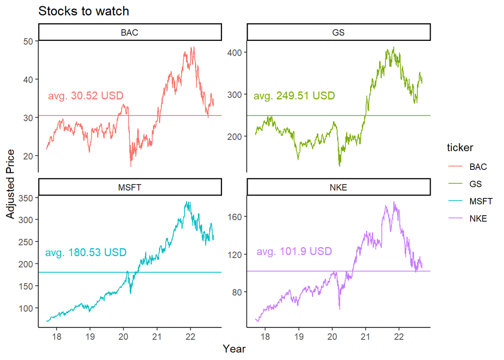

```r
# die durch das picking ausgewählten Unternehmen werden dem vektor ticker
# zugewiesen
ticker <- picks$Ticker

# Zählt 5 Jahre zurück und setzt dieses Datum als Start Datum für die Graphen
start_date <- ymd(format(Sys.Date())) - years(5)

# läd die Preis Daten im Zeitraum t - 5 Jahre und heute herunter
prices <- tq_get(ticker,
                 from = start_date,
                 to = format(Sys.Date()),
                 get = "stock.prices")

# nennt die col symbol in ticker um (da bisher so gehandhabt)
prices <- prices %>%
    rename(
      ticker = symbol,
    )

# berechnet den Mittelwert der Preise für die ticker und fasst diese zusammen
mean_prices <- prices %>% group_by(ticker)%>%summarise(mean=mean(adjusted))

# erstellt einen data frame für die Währung in welcher die Unternehmensdaten
# veröffentlicht wurden arrangiert diese so, dass sie dem Unternehmen zugewiesen
# werden kann
curr <- picks %>% arrange(Ticker)
curr <- curr$Currency
curr <- data.frame(curr)
mean_prices <- bind_cols(mean_prices, curr)

# plottet ein linien diagram aus den Unternehmen
print(picksplot <- prices %>%
          ggplot(aes(x = date, y = adjusted, color = ticker)) +
          geom_line()+
          # fügt eine linie ein, welche den mittelwert abbildet
          geom_hline(data = mean_prices, aes(yintercept = mean, color = ticker))+
          # sapltet die sonst in einem diagramm dargestellten 4 Unternehmen
          # in 4 einzelne diagramme auf
          facet_wrap(~ticker,scales = 'free_y')+
          # sauberers theme
          theme_classic()+
          # bennent den Titel und x und y Achse des Diagramms
          labs(x = 'Year',
           y = "Adjusted Price",
           title = "Stocks to watch") +
           scale_x_date(date_breaks = "year",
               date_labels = "%y")+
          # Fügt den Mittelwert incl. der Währung über der Mittelwertlinie ein
          geom_text(data = mean_prices, aes(x = prices$date[300], y = mean,
                    label = paste("avg.", round(mean,2), curr), vjust = -2),
                    show.legend = F))
```

```r
# Es wird ein Unternehmen ausgewählt, welches einer genaueren
# Betrachtung unterzogen werden soll
ticker <- "NKE"
Ticker <- data.frame(ticker)

# Da die Daten im ersten scraping durchgang nicht einheitlich sind, da Zeit
# bei den Banken gespart werden soll, müssen hier die Geschäftszahlen
# erneut gescraped und die Berechnungen angewand werden
Stock <- basics_assignement(Ticker)
scraped_DCF_data <- lapply(ticker, DCF_data_scraper)
DCF_calc_data <- DCF_calculation()
WACC_data <- WACC_calculation()

# ermöglicht kürzere variablen namen für den zugriff auf Daten
attach(DCF_calc_data$calended_data)

DCF_data_CYE <- data.frame(DCF_calc_data$calended_data[2:9])
# stellt alle Daten in Millionen $ dar
DCF_data_CYE <- round(DCF_data_CYE[1:8]/1000000)
# Wachstunmsrate des Revnues
p_growth_Rev <- c("-", (TotalRevenue[2:9]/TotalRevenue[1:8]-1))
# Fügt die col nach der col mit dem namen TotalRevenue ein
DCF_data_CYE <- add_column(DCF_data_CYE, p_growth_Rev = p_growth_Rev,
                           .after = "TotalRevenue")
# Berechnet den Operating Margin
Operating_Margin <- EBIT[1:9]/TotalRevenue[1:9]
DCF_data_CYE <- add_column(DCF_data_CYE, Operating_Margin = Operating_Margin,
                           .after = "EBIT")
# Anteil der Steuern am EBIT
p_of_EBIT <- IncTaxEx[1:9]/EBIT[1:9]
DCF_data_CYE <- add_column(DCF_data_CYE, p_of_EBIT = p_of_EBIT,
                           .after = "IncTaxEx")
# Anteil der D&A am Revenue
DandA_p_of_Rev <- DandA[1:9]/TotalRevenue[1:9]
DCF_data_CYE <- add_column(DCF_data_CYE, DandA_p_of_Rev = DandA_p_of_Rev,
                           .after = "DandA")
# Anteil der CapEx am Revenue
CapEx_p_of_Rev <- CAPEX[1:9]/TotalRevenue[1:9]
DCF_data_CYE <- add_column(DCF_data_CYE, CapEx_p_of_Rev = CapEx_p_of_Rev,
                           .after = "CAPEX")
# Anteil der change in NWC am Revenue
cNWC_p_of_Rev <- cNWC[1:9]/TotalRevenue[1:9]
DCF_data_CYE <- add_column(DCF_data_CYE, cNWC_p_of_Rev = cNWC_p_of_Rev,
                           .after = "cNWC")
# Wachstumsrate des FCF
p_growth_FCF <- c("-", (FCF[2:9]/FCF[1:8]-1))
DCF_data_CYE <- add_column(DCF_data_CYE, p_growth_FCF = p_growth_FCF,
                           .after = "FCF")
# Present value of FCF
pres_val_of_FCF <- c(rep(NA,4),round((FCF[5:9]/
              (1+WACC_data$T0_cal$RRR)^as.numeric(DiscountYear[5:9])/1000000)))
pres_val_of_FCF <- data.frame(pres_val_of_FCF)
DCF_data_CYE <- bind_cols(DCF_data_CYE,pres_val_of_FCF)
# detach die Daten wieder, damit keine Maskierung entstht
detach(DCF_calc_data$calended_data)

# entfernt die ersten beiden Reihen
DCF_data_CYE <- DCF_data_CYE[3:9,]
# wandelt nicht numerische charaktere in numerische um
DCF_data_CYE$p_growth_Rev <- as.numeric(DCF_data_CYE$p_growth_Rev)
DCF_data_CYE$p_growth_FCF <- as.numeric(DCF_data_CYE$p_growth_FCF)
# dreht tabelle, damit die col jetzt rows sind
DCF_data_CYE <- t(DCF_data_CYE)

# erstellt einen dataframe für die Jahre
Year <- DCF_calc_data$calended_data$Year[3:4]
Year <- c(Year, paste0(Year[2]+1, "E"), paste0(Year[2]+2, "E"),
          paste0(Year[2]+3, "E"), paste0(Year[2]+4, "E"), paste0(Year[2]+5, "E"))
colnames(DCF_data_CYE) <- Year

# erstellt den Vektor Year mit den gewünschten Namen der Rows
Year <- c("Revenue","growth y-o-y", "EBIT", "Operating margin",
                             "Taxes","% of EBIT", "D&A", "% of revenue", "CapEx",
                             "% of revenue", "Change in NWC", "% of revenue",
                             "EBIAT", "uFCF", "growth y-o-y",  "Present value of FCF" )

# wandelt den data frame in einen tibble um, dieser kann mit dem gt packege als
# schöne tabellen dargestellt werden und fügt die col Year am beginn des tibble
# ein
DCF_data_CYE <- as_tibble(DCF_data_CYE)
DCF_data_CYE <- DCF_data_CYE %>% add_column(Year, .before = "2021")

# erstellt aus dem tibble eine Tabelle
DCF_table_CYE <- gt(DCF_data_CYE)

# veränderungen an der Tabelle
DCF_table_CYE <-
  DCF_table_CYE %>%
  # gibt der Tabelle einen Titel und Untertitel, mit glue können Variablen
  # eingefügt werden, ähnlich wie mit paste, jedoch kürzer bei mehreren, hier
  # eventuell unnötig
  tab_header(
    title = glue("{Stock$list$Company} Discounted Cash Flow"),
    subtitle = glue("{Stock$list$Currency} in millions")
  ) %>%
  # wandelt die Daten in den cols und rows in % um und rundet diese auf eine
  # Nachkommastelle
  fmt_percent(
    columns = c(2:8),
    rows = c(2,4,6,8,10,12,15),
    decimals = 1
  ) %>%
  # Fügt den Daten in den cols und rows ein $ hinzu und rundet diese auf 0
  # Nachkommastelle
    fmt_currency(
    columns = c(2:8),
    rows = c(1,3,5,7,9,11,13,14,16),
    currency = "USD",
    decimals = 0
    ) %>%
  # erlaubt das Färben von Zellen
  tab_style(
    style = list(
      cell_fill(color = "deepskyblue2")
    ),
    # Fräbt Zellen in den angegeben cols und rows
    locations = cells_body(
      columns = c(2:8),
      rows = 14)
  ) %>%
  tab_style(
    style = list(
      cell_fill(color = "deepskyblue2")
    ),
    # Fräbt Zellen in den angegeben cols und rows
    locations = cells_body(
      columns = c(4:8),
      rows = 16)
)
rm(Year,start_date,p_of_EBIT,p_growth_Rev,p_growth_FCF,Operating_Margin,droping,
   DandA_p_of_Rev,cNWC_p_of_Rev,CapEx_p_of_Rev, ticker)
DCF_table_CYE
```

[output not shown]

```r
# Berechnet die ISP daten
ISP_data <- Imp_Share_Price_calculation()

attach(ISP_data)
attach(scraped_DCF_data[[1]]$T0Data)
attach(Stock$list)
# berechnet den Discount zwischen Preis und ISP
Discount <- 1-as.numeric(Price)/ISP
Discount <- data.frame(Discount)
PTermValue <- data.frame(PTermValue)
EntpriVal <- data.frame(EntpriVal)
EquValue <- data.frame(EquValue)
floatshares <- data.frame(floatshares)
ISP <- data.frame(ISP[1])
Price <- data.frame(Price)
Tot_PV_p_FCF <- sum(as.numeric(PUnlevFCF))
Tot_PV_p_FCF <- data.frame(Tot_PV_p_FCF)
detach(ISP_data)
detach(scraped_DCF_data[[1]]$T0Data)
detach(Stock$list)

# Berechnet den summierten present value des FCF

PPS_data <- bind_cols(Tot_PV_p_FCF,PTermValue,EntpriVal,EquValue,
                      floatshares, ISP, Price, Discount )

PPS_data$Price <- as.numeric(PPS_data[7])
# Stellt die Zahlen in millionen dar
PPS_data[1:5] <- round(PPS_data[1:5]/1000000)
# dreht die den data frame
PPS_data <- t(PPS_data)
# weist der Varibalen das aktuelle Jahr zu(ohne Monat und Tag)
curYear <- format(Sys.Date())
curYear <- year(curYear)

colnames(PPS_data) <- curYear
Year <- c("Total PV of proj. FCF", "PV Terminal VAlue", "Enterprise Value",
          "Equity Value", "Shares outstanding", "Implied Share Price",
          "Current Share Price", "Discount")

# erstellt einen tibble und erweitert den data frame um das aktuelle Jahr
PPS_data <- as_tibble(PPS_data)
PPS_data <- PPS_data %>% add_column(Year, .before = "2022")

# erstellt mit gt eine schöne Tabelle
PPS_table <- gt(PPS_data)

# Veränderungen an der Tabelle
PPS_table <-
  PPS_table %>%
  tab_header(
    # erstellt einen Titel und Untetitel
    title = "Price per Share",
    subtitle = glue("Numbers in millions, unless otherwise stated")
  ) %>%
  # stellt die Zahlen der Zellen in Prozent mit einer Nachkommastelle dar
  fmt_percent(
    columns = `2022`,
    rows = 8,
    decimals = 1
  ) %>%
  # weist den Zahlen der Zellen ein Dollarzeichen zu
    fmt_currency(
    columns = `2022`,
    rows = c(1,2,3,4,6,7),
    currency = "USD",
    decimals = 0
    )  %>%
  tab_footnote(
    # weist den Zahlen der Zellen eine Fußnote zu
    footnote = "not in millions",
    locations = cells_body(
    columns = 1,
    rows = 6:8)
  ) %>%
  # fräbt die Zelle ein
tab_style(
    style = list(
      cell_fill(color = "deepskyblue2")
    ),
    locations = cells_body(
      columns = c(2),
      rows = 6)
)

rm(curYear, Discount, Tot_PV_p_FCF)
PPS_table
```

Price per Share

Numbers in millions, unless otherwise stated

| Year | 2022 |
| --- | --- |
| Total PV of proj. FCF | $33,296 |
| PV Terminal VAlue | $143,799 |
| Enterprise Value | $177,095 |
| Equity Value | $185,669 |
| Shares outstanding | 1248 |
| Implied Share Price<sup>1</sup> | $149 |
| Current Share Price<sup>1</sup> | $111 |
| Discount<sup>1</sup> | 25.5% |

<sup>1</sup> not in millions

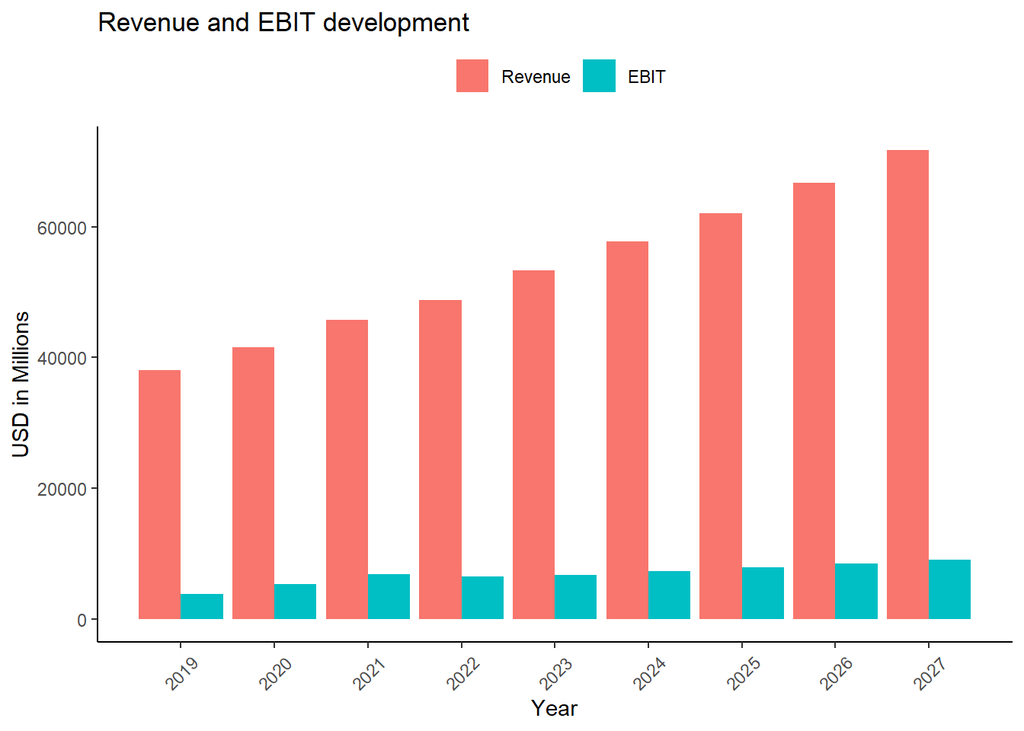

```r
# erstellt einen data frame für die graphische Projektion des EBIT und Revenues
bar_graph_data <- bind_cols(DCF_calc_data$calended_data[1],
                            round(DCF_calc_data$calended_data[2:3]/1000000))
colnames(bar_graph_data) <- c("Year","Revenue","EBIT")

# mithilfe der melt funktion wird der data frame so verschmolzen, das sich dieser
# besser für die darstellung eines bar graphs eignet, die id sind hier die Jahre
# und das Total Revenue und Ebit werden in einer col dargestellt
mel_bar_data <- reshape2::melt(bar_graph_data, id.var = "Year")

# erstellt einen bar graph
bar_graph_rev_EBIT  <- ggplot(mel_bar_data, aes(x=Year, y=value,
                                                fill = variable)) +
  geom_bar(stat = "identity", position = "dodge")+
  # classic theme für schönere Darstellung
  theme_classic()+
  # verschiebt die Legenede oberhalb des Graphens und entfernt den Legenden Namen
  theme(legend.position="top",
        legend.title=element_blank())+
  # ändert den y-Achsen Titel
  ylab("USD in Millions")+
  # passt die Beschriftung der x-Achse an und dreht diese um 45°
  theme(axis.text.x = element_text(angle = 45, vjust = 0.5))+
  # hiermit wird die x_Achsen Beschriftung konstant angezeigt wie sie im
  # data frame enthalten ist
  scale_x_continuous("Year", labels = as.character(bar_graph_data$Year),
                     breaks = bar_graph_data$Year)+
# Fügt dem Graphen einen Titel hinzu
 ggtitle("Revenue and EBIT development")
plot(bar_graph_rev_EBIT)
```

[figure not shown]

```r
# Vergleich von Nike mit dem SP500 und zwei Wettbewerbern
ticker <- c("NKE", "^GSPC","ADDYY", "UA" )

# Zählt 5 Jahre zurück
start_date <- ymd(format(Sys.Date())) - years(5)

# erstellt ein Datum für jedes Jahr der letzten 5 Jahre bis Heute
start_date <- start_date + days(2)
year1 <- start_date + years(1)
year2 <- start_date + years(2)
year3 <- start_date + years(3) + days(2)
year4 <- start_date + years(4) + days(2)
lastdate <- ymd(format(Sys.Date())) - days(2)

# entnimmt die Preise für die eingefügten Ticker (incl. Volumen)
prices <- tq_get(ticker,
                 from = start_date,
                 to = format(Sys.Date()),
                 get = "stock.prices")

# ändert den col Namen symbol zu ticker
prices <- prices %>%
    rename(
      ticker = symbol,
    )
# erstellt einen data frame mit den Preisen der letzten 5 Jahr eim Jahresabstand
# Achtung fehleranfällig wenn das das Datum nicht im df prices vorkommt
return_rate_d <- prices[prices$date == start_date, ]
return_rate_d <- bind_rows(return_rate_d, prices[prices$date == year1, ],
               prices[prices$date == year2, ],
               prices[prices$date == year3, ],
               prices[prices$date == year4, ],
               prices[prices$date == lastdate, ])

# berechnet mit den Preisen des df return_rate_ddie return rate
# für die Unternehmen
return_rate_NKE <- return_rate_d[return_rate_d$ticker == "NKE", ]
return_rate_NKE <- (return_rate_NKE$adjusted[2:6]-
                    return_rate_NKE$adjusted[1:5])/return_rate_NKE$adjusted[1:5]

return_rate_SP500 <- return_rate_d[return_rate_d$ticker == "^GSPC", ]
return_rate_SP500 <- (return_rate_SP500$adjusted[2:6]-
                return_rate_SP500$adjusted[1:5])/return_rate_SP500$adjusted[1:5]

return_rate_adi <- return_rate_d[return_rate_d$ticker == "ADDYY", ]
return_rate_adi <- (return_rate_adi$adjusted[2:6]-
                    return_rate_adi$adjusted[1:5])/return_rate_adi$adjusted[1:5]

return_rate_ua <- return_rate_d[return_rate_d$ticker == "UA", ]
return_rate_ua <- (return_rate_ua$adjusted[2:6]-
                     return_rate_ua$adjusted[1:5])/return_rate_ua$adjusted[1:5]
# die Variable x stellt den eingestzten Wert ein, um das Wachstum der Unternehmen
# und SP500 zu vergleichen
x <- 1000

# Berechnet den Return der Unternehmen und des SP500 mit einem Startwert von
# 1000 $
m_return_NKE <- c(x, x*return_rate_NKE[1]+x, (x*return_rate_NKE[1]+x)*return_rate_NKE[2]+(x*return_rate_NKE[1]+x))
m_return_NKE <- c(m_return_NKE, m_return_NKE[3]*return_rate_NKE[3]+m_return_NKE[3])
m_return_NKE <- c(m_return_NKE, m_return_NKE[4]*return_rate_NKE[4]+m_return_NKE[4])
m_return_NKE <- c(m_return_NKE, m_return_NKE[5]*return_rate_NKE[5]+m_return_NKE[5])
m_return_NKE <- data.frame(m_return_NKE)

m_return_SP500 <- c(x, x*return_rate_SP500[1]+x, (x*return_rate_SP500[1]+x)*return_rate_SP500[2]+(x*return_rate_SP500[1]+x))
m_return_SP500 <- c(m_return_SP500, m_return_SP500[3]*return_rate_SP500[3]+m_return_SP500[3])
m_return_SP500 <- c(m_return_SP500, m_return_SP500[4]*return_rate_SP500[4]+m_return_SP500[4])
m_return_SP500 <- c(m_return_SP500, m_return_SP500[5]*return_rate_SP500[5]+m_return_SP500[5])
m_return_SP500 <- data.frame(m_return_SP500)

m_return_adi <- c(x, x*return_rate_adi[1]+x, (x*return_rate_adi[1]+x)*return_rate_adi[2]+(x*return_rate_adi[1]+x))
m_return_adi <- c(m_return_adi, m_return_adi[3]*return_rate_adi[3]+m_return_adi[3])
m_return_adi <- c(m_return_adi, m_return_adi[4]*return_rate_adi[4]+m_return_adi[4])
m_return_adi <- c(m_return_adi, m_return_adi[5]*return_rate_adi[5]+m_return_adi[5])
m_return_adi <- data.frame(m_return_adi)

m_return_ua <- c(x, x*return_rate_ua[1]+x, (x*return_rate_ua[1]+x)*return_rate_ua[2]+(x*return_rate_ua[1]+x))
m_return_ua <- c(m_return_ua, m_return_ua[3]*return_rate_ua[3]+m_return_ua[3])
m_return_ua <- c(m_return_ua, m_return_ua[4]*return_rate_ua[4]+m_return_ua[4])
m_return_ua <- c(m_return_ua, m_return_ua[5]*return_rate_ua[5]+m_return_ua[5])
m_return_ua <- data.frame(m_return_ua)

Year <- year(c(start_date,year1,year2,year3,year4,lastdate))
Year <- data.frame(Year)



# erstellt einen df aus den variablen der returns, kurzzeitig ungünstige col
# namen
return_df <- bind_cols(Year, m_return_NKE, m_return_SP500, m_return_adi, m_return_ua)

return_df <- return_df %>%
    rename(
      Nike = m_return_NKE,
      SP500 = m_return_SP500,
      Adidas = m_return_adi,
      UA = m_return_ua
    )

# wandelt den df um
mel_return_df <- reshape2::melt(return_df, id.var = "Year")
mel_return_df$value <- round(mel_return_df$value)

# entnimmt dem df nur die Werte des aktuellen Jahres und zieht das
# eingesetzte Investment ab
return_to_date <- return_df[return_df$Year == "2022", ]
return_to_date <- return_to_date[2:5]-1000

# Berechnet den Jährlichen Return über die letzten 5 Jahre
avg_RR <- ((return_to_date[1:4]/1000*100)/5)

return_to_date <- bind_rows(return_to_date,avg_RR)
# dreht die Tabelle durch verschieben der cols zu rows
return_to_date <- t(round(return_to_date,2))

colnames(return_to_date) <- c("return in $","Yearly avg. return [%]")

# weißt der variable ein das minimal theme zu, damit dieses im folgenden graphen
# auf die in den Graphen eingefügte Tabelle angewandt werden kann, was die Optik
# verbessert
tt2 <- ttheme_minimal()
# erstellt ein Diagramm für das return auf ein investment von 1000 $
return_plot <- mel_return_df %>%
          ggplot(aes(x = Year, y = value, color = variable)) +
          # Liniendiagramm
          geom_line()+
          # zusätzlich Punkte zu besseren veranschaulichung der Daten
          geom_point()+#
          theme_classic()+
          theme(legend.position="top",
          legend.title=element_blank())+
          labs(x = 'Year',
           y = "Return in USD",
           title = "Return on investment of 1000$")+
        # fügt den df return_to_date mit dem theme tt2 in den plot ein
        annotation_custom(tableGrob(return_to_date, theme = tt2),
                    xmin=2018.2, xmax=2018.3, ymin=2000, ymax=3000)

print(return_plot)
```

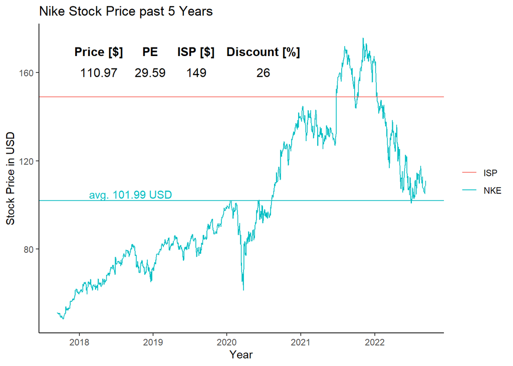

```r
# Erstellen eines PLots nur für Nike und einfügen der Kerndaten
ticker <- "NKE"

# entnimmt die Preise für die eingefügten Ticker (incl. Volumen)
prices <- tq_get(ticker,
                 from = start_date,
                 to = format(Sys.Date()),
                 get = "stock.prices")

# ändert den col Namen symbol zu ticker
prices <- prices %>%
    rename(
      ticker = symbol,
    )
# durschnittlicher Aktienkurs der letzten 5 Jahre von Nike
mean_NKE_price <- round(mean(prices$adjusted),2)
mean_NKE_price <- data.frame(mean_NKE_price)

# Fügt Kerndaten zu einem df zusammen
Stock_info <- c(Stock$list[5],Stock$list[6],
                        PPS_data$`2022`[6], round(PPS_data$`2022`[8]*100))
Stock_info <- data.frame(Stock_info)

# erstellt einen plot für den ticker in welchem Kerndaten enthalten sind
# sowie der Aktienkurs der ltezten 5 Jahre
ticker_plot <- prices %>%
          ggplot(aes(x = date, y = adjusted, color = ticker)) +
          geom_line()+
          # fügt den Mittelwert in Form einer Linie ein
          geom_hline(data = mean_NKE_price, aes(yintercept = mean_NKE_price,
                                                color = ticker))+
          # fügt den Implied Share Price in Form einer Linie ein
          geom_hline(data = Stock_info, aes(yintercept = X149, colour = "ISP"),
                                                show.legend = F)+
          theme_classic()+
          labs(x = 'Year',
           y = "Stock Price in USD",
           title = "Nike Stock Price past 5 Years")+
          # fügt den Linien ober die dazugehörende Werten hinzu
          geom_text(data = mean_NKE_price, aes(x = prices$date[250],
                                              y = mean_NKE_price,
                                              label = paste("avg.",
                                            mean_NKE_price, Stock$list$Currency),
                                            vjust = -0.3), show.legend = F)+
          theme(legend.position="right",
          legend.title=element_blank())

# entfernt optisch den Reihennamen damit die Tabelle besser im Plot aussieht
rownames(Stock_info) <- ""

Stock_info <- Stock_info %>%
    rename(
      "Price [$]" = Price,
      "ISP [$]" = X149,
      "Discount [%]" = X26,
    )
# fügt den df Stock_Info mit dem theme tt2 in den plot ein
ticker_plot <- ticker_plot +
  annotation_custom(tableGrob(Stock_info, theme = tt2), xmin=prices$date[400],
                    xmax=prices$date[450], ymin=160, ymax=170)
print(ticker_plot)
```

Borowski, Max. 2021. “Die Neuen Corona-Aktionäre.” *N-TV Nachrichten*. n-tv NACHRICHTEN. https://www.n-tv.de/wirtschaft/Die-neuen-Corona-Aktionaere-article22267264.html.

Damadoran, Aswath. n.d. “Chapter 15:FIRM VALUATION: COST OF CAPITAL AND APV APPROACHES.” *Damodaran Online*. https://pages.stern.nyu.edu/~adamodar/pdfiles/valn2ed/.

Damodaran, Aswath. 2022. “Country Default Spreads and Risk Premiums.” *Pages at the Stern School of Business, New York University*. https://pages.stern.nyu.edu/~adamodar/New_Home_Page/datafile/ctryprem.html.

Dong, Yanqing. 2018. “Enterprise Value Evaluation Based on FCFF Model - a Case Analysis of Beixinyuan Company.” *Proceedings of the 2nd International Conference on Economics and Management, Education, Humanities and Social Sciences (EMEHSS 2018)*. https://doi.org/10.2991/emehss-18.2018.124.

Grüninger, Matthias C., and Axel H. Kind. 2013. “WACC Calculations in Practice: Incorrect Results Due to Inconsistent Assumptions - Status Quo and Improvements.” *Accounting and Finance Research* 2 (2). https://doi.org/10.5430/afr.v2n2p36.

Lee, Charles M., James Myers, and Bhaskaran Swaminathan. 1999. “What Is the Intrinsic Value of the Dow?” *The Journal of Finance* 54 (5): 1693–1741. https://doi.org/10.1111/0022-1082.00164.